# p8105_hw3_cw3370

# Problem 1

The goal is to do some exploration of this dataset. To that end, write a short description of the dataset, noting the size and structure of the data, describing some key variables, and giving illstrative examples of observations. Then, do or answer the following

```r
data("instacart")
force(instacart)
```

Instacart includes 1384617 observations for 15 variables. For variables, they are order_id, product_id, add_to_cart_order, reordered, user_id, eval_set, order_number, order_dow, order_hour_of_day, days_since_prior_order, product_name, aisle_id, department_id, aisle, department.

order_id is the order id.

product_id, product_name is the id and name of product, which are the key variable.

add_to_cart_order is order in which each product was added to cart.

reordered shows whether the user bought this product before.

user_id is the user id.

order_number, order_hour_of_dayis the order sequence number for user, the day of week and the hour of day order was placed.

days_since_prior_order is days since the last order.

aisle_id, aisle is the id and name of aisle, which are the key variable.

department_id, department is the id and name of department.

For example, the first observation shows a customer whose user id is 112108, buy Bulgarian Yogurt(product id:49302) for the 1 time at 10 o’clock in the 4 day of week,which is the 1 product in this order. This product belongs to yogurt aisle(aisle id:120) and dairy eggs department(department id:16).

How many aisles are there, and which aisles are the most items ordered from?

```r
nrow(distinct(instacart,aisle))
```

```
## [1] 134
```

```r
most_items_aisle <- instacart %>%
  group_by(aisle) %>%
  summarize(n_items = n()) %>%
  arrange(desc(n_items))
```

There are 134 aisles and fresh vegetables is the most items ordered from.

Make a plot that shows the number of items ordered in each aisle, limiting this to aisles with more than 10000 items ordered. Arrange aisles sensibly, and organize your plot so others can read it.

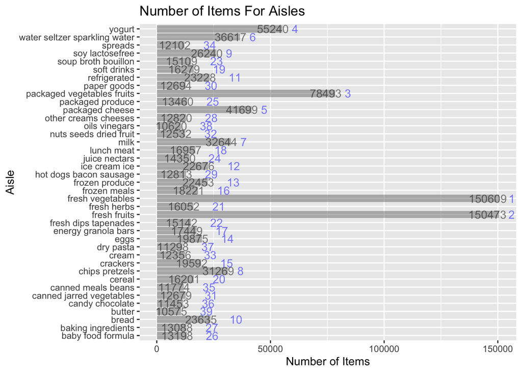

```r
number_items_aisle <- instacart %>%
  count(aisle) %>%
  filter(n > 10000) %>%
  mutate(
    rank = rank(desc(n))
  )

## blue number means the rank, black number means the number of items.
ggplot(data = number_items_aisle,aes(x = aisle, y = n)) +
  geom_bar(alpha = 0.4, stat = "identity") +
  geom_text(aes(label = n,hjust = 0.8),alpha = 0.5) +
  geom_text(aes(label = rank,hjust = -1.5),color ="blue",alpha = 0.5) +
  labs(title = "Number of Items For Aisles", x = "Aisle",y = "Number of Items" ) +
  coord_flip()
```

Make a table showing the three most popular items in each of the aisles “baking ingredients”, “dog food care”, and “packaged vegetables fruits”. Include the number of times each item is ordered in your table.

```r
most_popular_items <- instacart %>%
  filter(aisle ==  "baking ingredients" | aisle == "dog food care"|aisle == "packaged vegetables fruits") %>%
  group_by(aisle,product_name) %>%
  summarize(Number = n()) %>%
  mutate(popular_rank = order(order(Number, decreasing = TRUE))) %>%
  filter(popular_rank %in% c(1:3)) %>%
  arrange(aisle,desc(Number))
knitr::kable(most_popular_items)
```

| aisle | product_name | Number | popular_rank |
| --- | --- | --- | --- |
| baking ingredients | Light Brown Sugar | 499 | 1 |
| baking ingredients | Pure Baking Soda | 387 | 2 |
| baking ingredients | Cane Sugar | 336 | 3 |
| dog food care | Snack Sticks Chicken & Rice Recipe Dog Treats | 30 | 1 |
| dog food care | Organix Chicken & Brown Rice Recipe | 28 | 2 |
| dog food care | Small Dog Biscuits | 26 | 3 |
| packaged vegetables fruits | Organic Baby Spinach | 9784 | 1 |
| packaged vegetables fruits | Organic Raspberries | 5546 | 2 |
| packaged vegetables fruits | Organic Blueberries | 4966 | 3 |

Make a table showing the mean hour of the day at which Pink Lady Apples and Coffee Ice Cream are ordered on each day of the week; format this table for human readers (i.e. produce a 2 x 7 table)

```r
## l adjust the order time into hour,minute,second
mean_hour_of_order <- instacart %>%
  filter(product_name == "Pink Lady Apples"|product_name == "Coffee Ice Cream") %>%
  select(order_dow,order_hour_of_day,product_name) %>%
  group_by(product_name,order_dow) %>%
  summarize(mean_hour = mean(order_hour_of_day)) %>%
  mutate(order_dow = recode(order_dow ,
                            '0' = "Sunday",'1' = "Monday",'2' = "Tuesday",
                            '3' = "Wednesday",'4' = "Thursday",'5' = "Friday",'6' = "Saturday"),
         hour = mean_hour %/% 1,
         minute = (mean_hour %% 1*60) %/% 1,
         second = round(round((mean_hour %% 1*60) %% 1,5)*60),
         time = hms(paste(hour,minute,second,sep = ":"))
         ) %>%
  select(product_name,order_dow,time) %>%
  pivot_wider(
    names_from = "order_dow",
    values_from = "time"
  )
knitr::kable(mean_hour_of_order)
```

| product_name | Sunday | Monday | Tuesday | Wednesday | Thursday | Friday | Saturday |
| --- | --- | --- | --- | --- | --- | --- | --- |
| Coffee Ice Cream | 13H 46M 27S | 14H 18M 57S | 15H 22M 51S | 15H 19M 5S | 15H 13M 3S | 12H 15M 47S | 13H 50M 0S |
| Pink Lady Apples | 13H 26M 28S | 11H 21M 36S | 11H 42M 8S | 14H 15M 0S | 11H 33M 6S | 12H 47M 4S | 11H 56M 15S |

#Problem 2 Do some data cleaning

```r
data("brfss_smart2010")
force(brfss_smart2010)

brfss_smart2010 <- brfss_smart2010 %>%
  filter(Topic == "Overall Health" & Response %in% c("Excellent","Very good","Good","Fair","Poor")) %>%
  mutate(
    Response = factor(Response,ordered = TRUE,levels = c("Poor","Fair","Good","Very good","Excellent"))
  )
```

In 2002, which states were observed at 7 or more locations? What about in 2010?

```r
locations_observed_2002 <-
  brfss_smart2010 %>%
  separate(Locationdesc,into = c("state","Location"),sep = 5) %>%
  select(-state,State = Locationabbr) %>%
  filter(Year == 2002) %>%
  group_by(State)%>%
  summarize(location_number = n()/5) %>%
  filter(location_number >=7)

locations_observed_2010 <-
  brfss_smart2010 %>%
  separate(Locationdesc,into = c("state","Location"),sep = 5) %>%
  select(-state,State = Locationabbr) %>%
  filter(Year == 2010) %>%
  group_by(State) %>%
  summarize(location_number = n()/5) %>%
  filter(location_number >= 7)

knitr::kable(locations_observed_2002)
```

| State | location_number |
| --- | --- |
| CT | 7 |
| FL | 7 |
| MA | 8 |
| NC | 7 |
| NJ | 8 |
| PA | 10 |

```r
knitr::kable(locations_observed_2010)
```

| State | location_number |
| --- | --- |
| CA | 12 |
| CO | 7 |
| FL | 41 |
| MA | 9 |
| MD | 12 |
| NC | 12 |
| NE | 10 |
| NJ | 19 |
| NY | 9 |
| OH | 8 |
| PA | 7 |
| SC | 7 |
| TX | 16 |
| WA | 10 |

Construct a dataset that is limited to Excellent responses, and contains, year, state, and a variable that averages the data_value across locations within a state. Make a “spaghetti” plot of this average value over time within a state (that is, make a plot showing a line for each state across years – the geom_line geometry and group aesthetic will help).

```r
average_excellent <-
  brfss_smart2010 %>%
  filter(Response == "Excellent") %>%
  select(Year, State = Locationabbr, Data_value) %>%
  group_by(Year,State) %>%
  summarize(
    mean_value = mean(Data_value,na.rm = TRUE),
    )
```

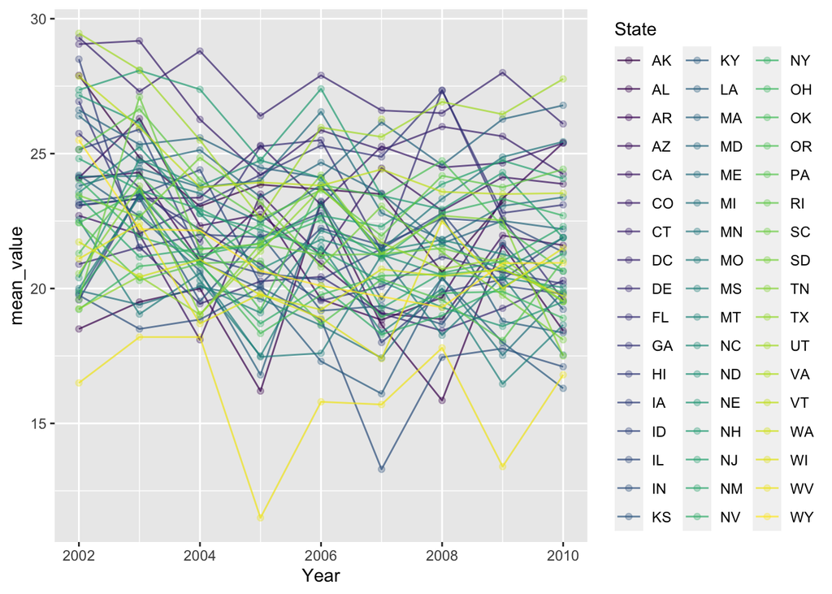

```r
ggplot(average_excellent,aes(x = Year, y = mean_value,group = State, color = State))+
  geom_point(alpha = 0.3) +
  geom_line(alpha = 0.7)
```

Make a two-panel plot showing, for the years 2006, and 2010, distribution of data_value for responses (“Poor” to “Excellent”) among locations in NY State.

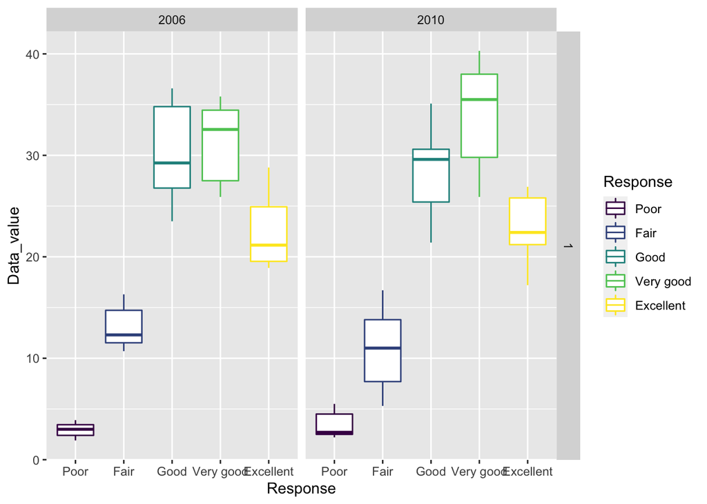

```r
distribution_response <-
  brfss_smart2010 %>%
  select(Year, Response,State = Locationabbr, Data_value) %>%
  filter(State == "NY",
         Year %in% c(2006,2010))

ggplot(distribution_response,aes(x = Response, y = Data_value))+
  geom_boxplot(aes(color = Response)) +
  facet_grid(1.~Year)
```

#Problem 3

```r
accelerometers_df <- read_csv("data/accel_data.csv")
```

```
## ─ Column specification ────────────────────────────
```

Load, tidy, and otherwise wrangle the data. Your final dataset should include all originally observed variables and values; have useful variable names; include a weekday vs weekend variable; and encode data with reasonable variable classes. Describe the resulting dataset (e.g. what variables exist, how many observations, etc).

```r
accelerometers_df_hm <- accelerometers_df %>%
  mutate(day_type = case_when(
    day %in% c("Monday","Tuesday","Wednesday","Thursday","Friday") ~ "weekday",
    day %in% c("Saturday","Sunday") ~ "weekend"
  )) %>%
  pivot_longer(
    activity.1:activity.1440,
    names_to = "Minute",
    names_prefix = "activity.",
    values_to = "activity"
  ) %>%
  mutate(activity = round(activity,2),
         Minute = as.numeric(Minute)-1,
         hour = Minute %/% 60,
         minute = Minute %% 60,
         day_of_week = recode(day,"Sunday" = "7","Monday"= "1","Tuesday"= "2","Wednesday"= "3", "Thursday"= "4","Friday"= "5","Saturday"= "6")) %>%
  arrange(week,day_of_week) %>%
  select(week,day_id,day,day_of_week,day_type,Minute,hour,minute,activity,)
```

Traditional analyses of accelerometer data focus on the total activity over the day. Using your tidied dataset, aggregate accross minutes to create a total activity variable for each day, and create a table showing these totals. Are any trends apparent?

```r
day_total_activity <- accelerometers_df_hm %>%
  group_by(week,day_of_week) %>%
  summarize(
    total_activity = sum(activity)
  ) %>%
  mutate(day_of_week_eng = recode(day_of_week,
                            '7' = "Sunday",'1' = "Monday",'2' = "Tuesday",
                            '3' = "Wednesday",'4' = "Thursday",'5' = "Friday",'6' = "Saturday"))
knitr::kable(day_total_activity)
```

| week | day_of_week | total_activity | day_of_week_eng |
| --- | --- | --- | --- |
| 1 | 1 | 78828.18 | Monday |
| 1 | 2 | 307094.19 | Tuesday |
| 1 | 3 | 340115.01 | Wednesday |
| 1 | 4 | 355923.72 | Thursday |
| 1 | 5 | 480542.61 | Friday |
| 1 | 6 | 376254.00 | Saturday |
| 1 | 7 | 631105.00 | Sunday |
| 2 | 1 | 295431.00 | Monday |
| 2 | 2 | 423245.00 | Tuesday |
| 2 | 3 | 440962.00 | Wednesday |
| 2 | 4 | 474048.00 | Thursday |
| 2 | 5 | 568839.00 | Friday |
| 2 | 6 | 607175.00 | Saturday |
| 2 | 7 | 422018.00 | Sunday |
| 3 | 1 | 685910.00 | Monday |
| 3 | 2 | 381507.00 | Tuesday |
| 3 | 3 | 468869.00 | Wednesday |
| 3 | 4 | 371230.00 | Thursday |
| 3 | 5 | 467420.00 | Friday |
| 3 | 6 | 382928.00 | Saturday |
| 3 | 7 | 467052.00 | Sunday |
| 4 | 1 | 409450.00 | Monday |
| 4 | 2 | 319568.00 | Tuesday |
| 4 | 3 | 434460.00 | Wednesday |
| 4 | 4 | 340291.00 | Thursday |
| 4 | 5 | 154049.00 | Friday |
| 4 | 6 | 1440.00 | Saturday |
| 4 | 7 | 260617.00 | Sunday |
| 5 | 1 | 389080.00 | Monday |
| 5 | 2 | 367824.00 | Tuesday |
| 5 | 3 | 445366.00 | Wednesday |
| 5 | 4 | 549658.00 | Thursday |
| 5 | 5 | 620860.00 | Friday |
| 5 | 6 | 1440.00 | Saturday |
| 5 | 7 | 138421.00 | Sunday |

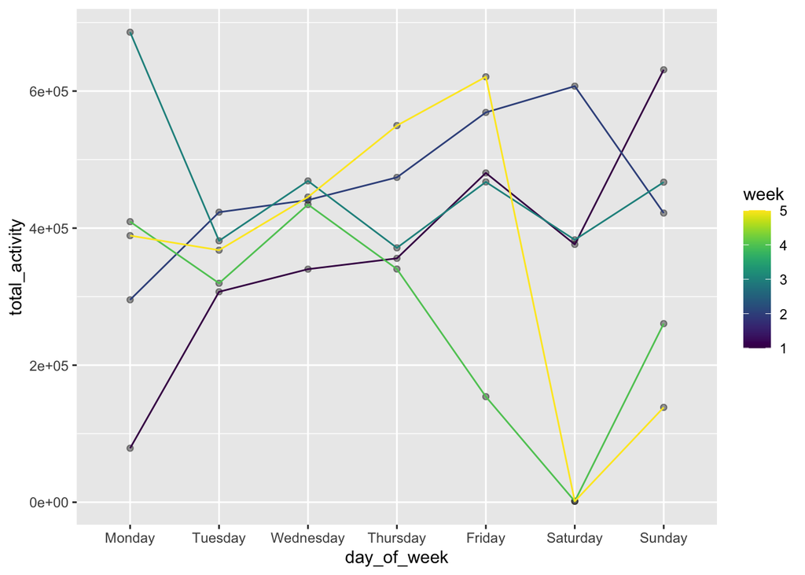

```r
ggplot(day_total_activity,aes(x = day_of_week, y = total_activity,group = week))+
  geom_point(alpha = 0.4)+
  geom_line(aes(color = week))+
  scale_x_discrete(breaks = c(1,2,3,4,5,6,7),
                   labels = c("Monday","Tuesday","Wednesday","Thursday","Friday","Saturday","Sunday"))+
  viridis::scale_color_viridis(
    name = "week",
    discrete = FALSE
  )
```

Accelerometer data allows the inspection activity over the course of the day. Make a single-panel plot that shows the 24-hour activity time courses for each day and use color to indicate day of the week. Describe in words any patterns or conclusions you can make based on this graph.

```r
daily_activity <- accelerometers_df_hm %>%
  group_by(week,day_of_week,hour) %>%
  summarize(
    hour_activity = sum(activity)
  )
```

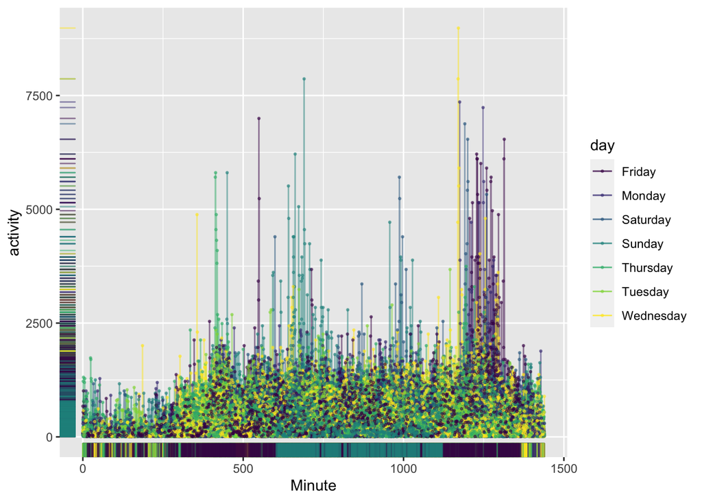

```r
accelerometers_df_hm %>%
  filter(activity != 1.00) %>%
  ggplot(aes(x = Minute , y = activity,group = day)) +
  geom_line(aes(color = day),alpha = 0.5) +
  geom_point(aes(color = day),alpha = 0.5,size = 0.5) +
  geom_rug(aes(color = day),alpha = 0.5)
```